# HW4: Nonlinear and Ensemble Modeling

李宜庭

### Packages

```r
library(epiDisplay)
library(corrplot)
library(tree)
library(randomForest)
library(gbm)
library(leaps)
library(ggplot2)
library(glmnet)
library(splines)
library(rsconnect)
```

## Problem 1: Bike Sharing Dataset

This data set collects the bike sharing counts aggregated on daily basis (2011-2012) together with the calender information (year/season/weekday/holiday) and daily weather conditions. There are 4 weather realted variables:

- weathersit: (GOOD, MISTY, RAIN/SNOW/STORM)
- temperature (in Celsius)
- humidity (relative to 100%)
- windspeed

The objective is to predict the bike sharing counts given a date, and figure out the impacts on the counts due to weather conditions.

### Your analysis should include the following:

- EDA and preliminary findings.
- Fit tree-based models and summarize their prediction performance. The tuning parameters for tree-based models should be determined via cross validation.
- Fit a linear regression and a nonlinear regression model for the target variable **count**. Again, your models should go through a proper model selection procedure. Summarize the selected models with their prediction performance.
- Identify the important input variables for predicting bike sharing counts. In particular, characterize the effects of weather conditions on the bike counts **quantitatively**.
- Give a brief analysis summary.

### Read data

```r
bike <- read.csv(file="bike.csv") #read data
head(bike)
```

```
##   days_since_2011 season year month    holiday weekday     workingday weather
## 1               1 WINTER 2011   JAN NO HOLIDAY     SAT NO WORKING DAY   MISTY
## 2               2 WINTER 2011   JAN NO HOLIDAY     SUN NO WORKING DAY   MISTY
## 3               3 WINTER 2011   JAN NO HOLIDAY     MON    WORKING DAY    GOOD
## 4               4 WINTER 2011   JAN NO HOLIDAY     TUE    WORKING DAY    GOOD
## 5               5 WINTER 2011   JAN NO HOLIDAY     WED    WORKING DAY    GOOD
## 6               6 WINTER 2011   JAN NO HOLIDAY     THU    WORKING DAY    GOOD
##       temp     hum windspeed count
## 1 8.175849 80.5833 10.749882   985
## 2 9.083466 69.6087 16.652113   801
## 3 1.229108 43.7273 16.636703  1349
## 4 1.400000 59.0435 10.739832  1562
## 5 2.666979 43.6957 12.522300  1600
## 6 1.604356 51.8261  6.000868  1606
```

```r
summary(bike)
```

```
##  days_since_2011    season               year         month
##  Min.   :  1.0   Length:731         Min.   :2011   Length:731
##  1st Qu.:183.5   Class :character   1st Qu.:2011   Class :character
##  Median :366.0   Mode  :character   Median :2012   Mode  :character
##  Mean   :366.0                      Mean   :2012
##  3rd Qu.:548.5                      3rd Qu.:2012
##  Max.   :731.0                      Max.   :2012
##    holiday            weekday           workingday          weather
##  Length:731         Length:731         Length:731         Length:731
##  Class :character   Class :character   Class :character   Class :character
##  Mode  :character   Mode  :character   Mode  :character   Mode  :character
##
##
##
##       temp             hum          windspeed          count
##  Min.   :-5.221   Min.   : 0.00   Min.   : 1.500   Min.   :  22
##  1st Qu.: 7.843   1st Qu.:52.00   1st Qu.: 9.042   1st Qu.:3152
##  Median :15.422   Median :62.67   Median :12.125   Median :4548
##  Mean   :15.283   Mean   :62.79   Mean   :12.763   Mean   :4504
##  3rd Qu.:22.805   3rd Qu.:73.02   3rd Qu.:15.625   3rd Qu.:5956
##  Max.   :32.498   Max.   :97.25   Max.   :34.000   Max.   :8714
```

### Data Structure Adjustment

First, convert categorical variables into factor. As for the year variable, since there are only two value in that column, so we decide to turn it into factor, too.

```r
bike$season<-factor(bike$season)
bike$year<-factor(bike$year)
bike$month<-factor(bike$month)
bike$holiday<-factor(bike$holiday)
bike$weekday<-factor(bike$weekday)
bike$workingday<-factor(bike$workingday)
bike$weather<-factor(bike$weather)
```

Since the meaning of “holiday” and “working” columns are a little bit ambiguous; therefore, we create a new column called “special day” that covers all range of day type. Class1-“WORKING DAY”: workingday=1, holiday=0 Class2-“HOLIDAY”: workingday=0, holiday=1 Class3-“WEEKEND”: workingday=0, holiday=0

```r
bike$specialday[bike$holiday=="HOLIDAY"]<-"HOLIDAY"
bike$specialday[bike$workingday=="WORKING DAY"]<-"WORKING DAY"
bike$specialday[(bike$holiday=="NO HOLIDAY")&(bike$workingday=="NO WORKING DAY")]<-"WEEKEND"
bike$specialday<-factor(bike$specialday)
```

### EDA

First, view distribution of count’s value for each class variable

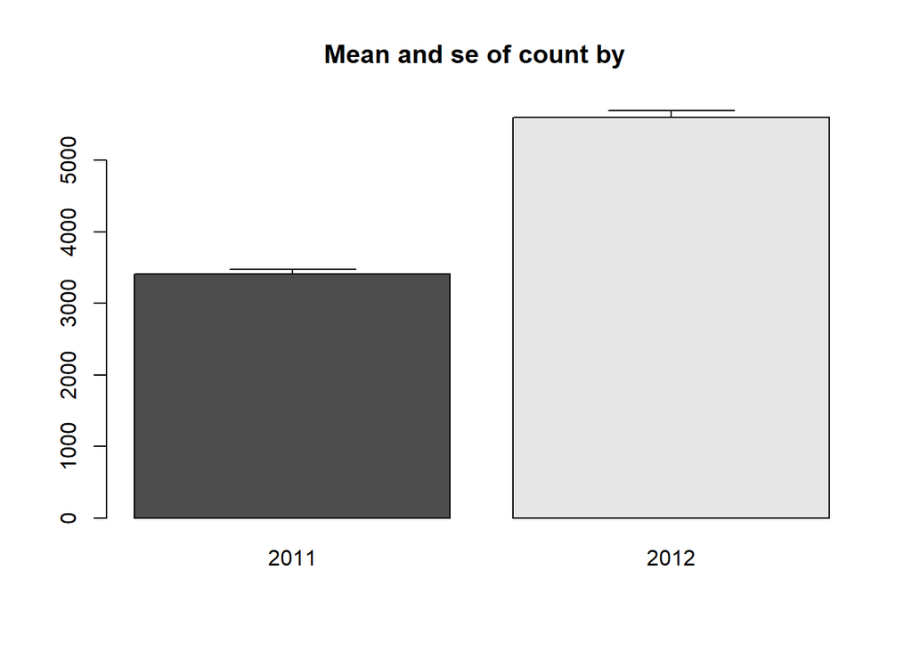

```
##   Var1     mean       se
## 1 2011 3405.762 72.16727
## 2 2012 5599.934 93.49517
```

```r
attach(bike)
aggregate.plot(x=count, by=list(year), return = TRUE,legend = "False")
```

By the above graphs, we can see that bike sharing count of year 2012 appears to be higher than that of year 2011.

As for month and season, we can’t easily observe trend for count distribution in each month class;by contrast, “season” column is more interpretable, we can see that bike sharing count in winter is significantly lower than other seasons.

```r
par(mfrow=c(1,2))
aggregate.plot(x=count, by=list(month), return = TRUE,legend = "False")
```

```
##    Var1     mean       se
## 1   APR 4484.900 229.3014
## 2   AUG 5664.419 189.8037
## 3   DEC 3403.806 196.8044
## 4   FEB 2655.298 151.7005
## 5   JAN 2176.339 147.5328
## 6   JUL 5563.677 161.7666
## 7   JUN 5772.367 160.1350
## 8   MAR 3692.258 241.2116
## 9   MAY 5349.774 164.9365
## 10  NOV 4247.183 165.9848
## 11  OCT 5199.226 252.5261
## 12  SEP 5766.517 233.6869
```

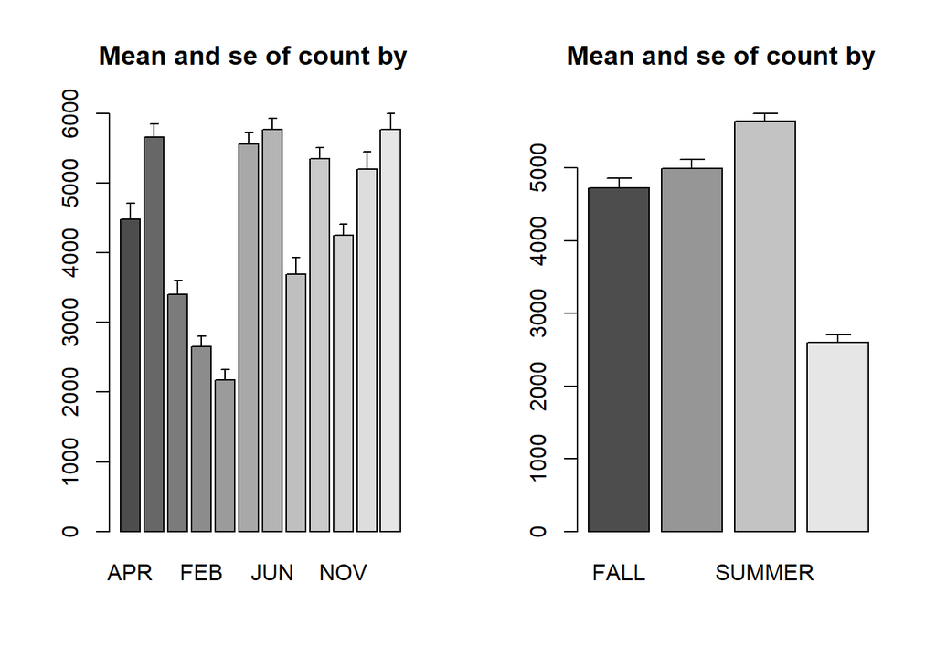

```
##     Var1     mean       se
## 1   FALL 4728.163 127.3915
## 2 SPRING 4992.332 125.0291
## 3 SUMMER 5644.303 106.4669
## 4 WINTER 2604.133 104.0569
```

```r
aggregate.plot(x=count, by=list(season), return = TRUE,legend = "False")
```

On the other hand, we compare “weekday” and “special day” columns. Similarly, we can’t observe any count distribution trend in the “weekday” column, and “special day” may be more easily to explain.

```r
par(mfrow=c(1,2))
aggregate.plot(x=count, by=list(weekday), return = TRUE,legend = "False")
```

```
##   Var1     mean       se
## 1  FRI 4690.288 183.8221
## 2  MON 4338.124 174.9861
## 3  SAT 4550.543 214.3753
## 4  SUN 4228.829 182.7370
## 5  THU 4667.260 190.1771
## 6  TUE 4510.663 179.1434
## 7  WED 4548.538 199.8517
```

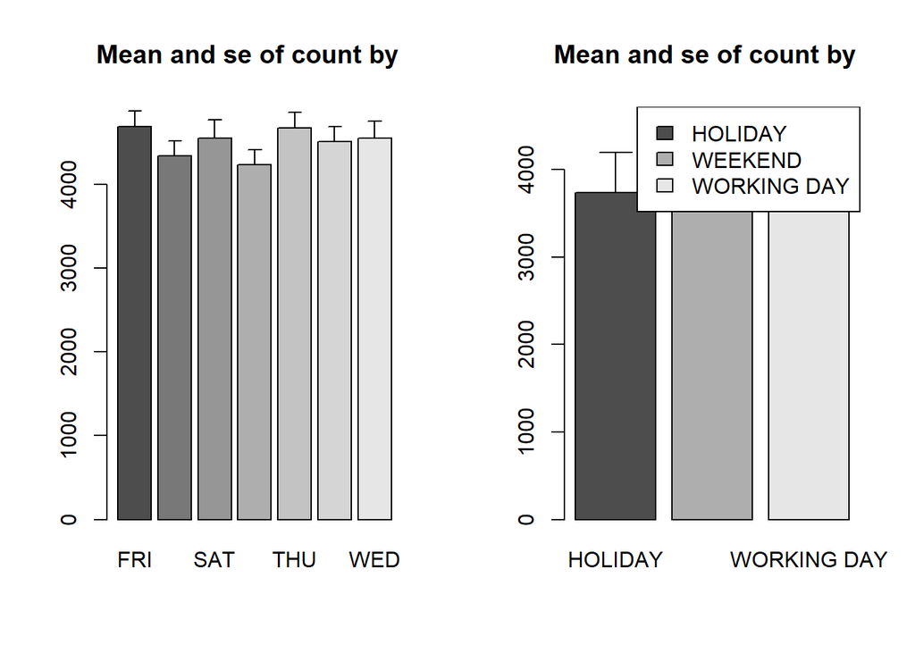

```
##          Var1     mean       se
## 1     HOLIDAY 3735.000 458.9887
## 2     WEEKEND 4389.686 140.9478
## 3 WORKING DAY 4584.820  84.0053
```

```r
aggregate.plot(x=count, by=list(specialday), return = TRUE)
```

Finally, let’s see the count distribution for the weather condition. The bike sharing count appears to be high in good weather condition, follows by misty, and special weather conditions such as rain/snow/storm have the least bike sharing count.

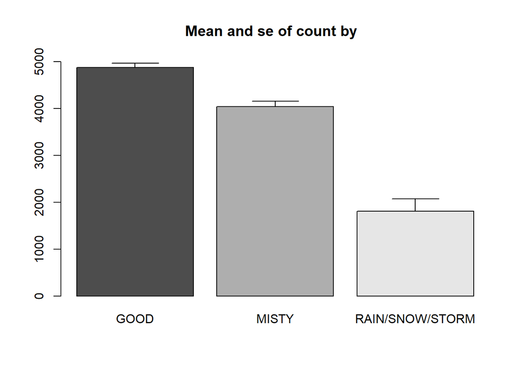

```
##              Var1     mean        se
## 1            GOOD 4876.786  87.34703
## 2           MISTY 4035.862 115.11091
## 3 RAIN/SNOW/STORM 1803.286 270.65226
```

```r
aggregate.plot(x=count, by=list(weather), return = TRUE,legend = "False")
```

After observing relationship between categorical and target variable, we then observe relationship between quantitative variables, and we can see that relationship between count and some variables may probably be nonlinear.

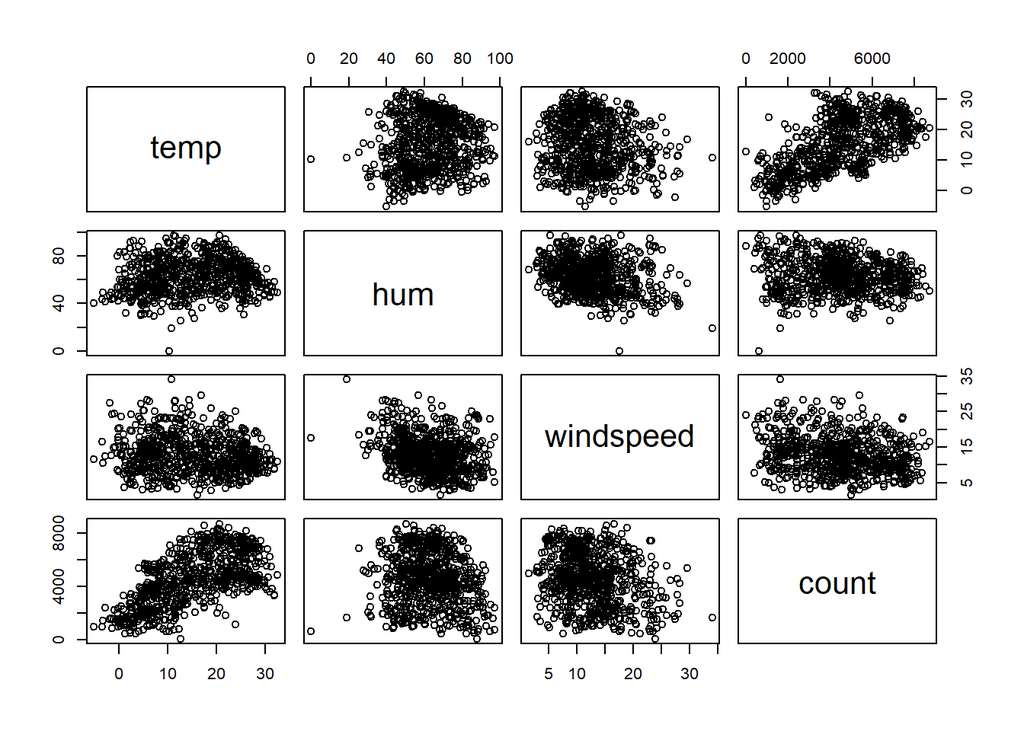

```r
pairs(bike[,c("temp","hum", "windspeed",    "count")])
```

### Decide a new dataframe

By the above description, we can know that compare to “weekday” and “month”, “special day” and “season” seem to be more interpretable. Therefore, we finally choose “year”, “season”, “specialday”, “weather”, “temp”, “hum”, “windspeed” to be the predictors of final dataframe.

```r
bike_new<-bike[,c("year","season","specialday","weather","temp","hum","windspeed","count")]
summary(bike_new)
```

```
##    year        season          specialday             weather
##  2011:365   FALL  :178   HOLIDAY    : 21   GOOD           :463
##  2012:366   SPRING:184   WEEKEND    :210   MISTY          :247
##             SUMMER:188   WORKING DAY:500   RAIN/SNOW/STORM: 21
##             WINTER:181
##
##
##       temp             hum          windspeed          count
##  Min.   :-5.221   Min.   : 0.00   Min.   : 1.500   Min.   :  22
##  1st Qu.: 7.843   1st Qu.:52.00   1st Qu.: 9.042   1st Qu.:3152
##  Median :15.422   Median :62.67   Median :12.125   Median :4548
##  Mean   :15.283   Mean   :62.79   Mean   :12.763   Mean   :4504
##  3rd Qu.:22.805   3rd Qu.:73.02   3rd Qu.:15.625   3rd Qu.:5956
##  Max.   :32.498   Max.   :97.25   Max.   :34.000   Max.   :8714
```

```r
dim(bike_new)
```

```
## [1] 731   8
```

### Split training and testing set

```r
set.seed(1)
train <- sample(1:nrow(bike_new), nrow(bike_new)*0.8)
test<-(-train)
bike.tr<-bike_new[train,]
bike.tst<-bike_new[test,]
bike.tr
```

[output not shown]

[output cut: 570 more lines]

### Model1: Tree

The first model is decision tree, we fit it into the training set, and visualize it.

```r
tree.bike <- tree(count ~ ., bike.tr)
summary(tree.bike)
```

```
##
## Regression tree:
## tree(formula = count ~ ., data = bike.tr)
## Variables actually used in tree construction:
## [1] "temp"   "year"   "season" "hum"
## Number of terminal nodes:  9
## Residual mean deviance:  739600 = 425300000 / 575
## Distribution of residuals:
##    Min. 1st Qu.  Median    Mean 3rd Qu.    Max.
## -4269.0  -477.7   118.0     0.0   566.6  2782.0
```

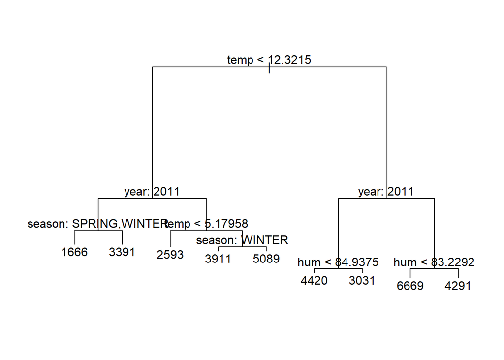

```r
plot(tree.bike);text(tree.bike,pretty = 0)
```

By the above tree, the most important indicator for bike sharing count appears to be “temperature”, and “year” plays an important role in both parts. We can clearly see that bike count in year 2012 is significantly higher than year2011. As for the following nodes, we can generally observe the effect caused by “season” and “humidity”, in spring or winter season, people rent less bike; and in high humidity weather condition, people rent less.

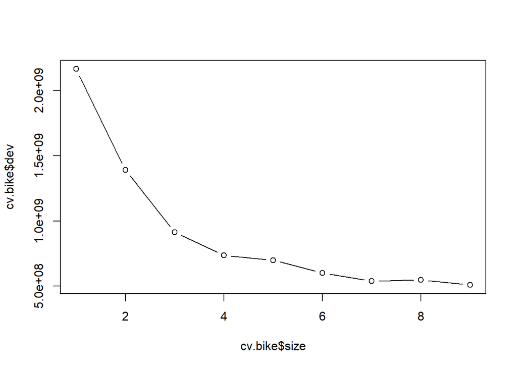

```r
cv.bike <- cv.tree(tree.bike)
plot(cv.bike$size, cv.bike$dev, type = "b")
```

By the cross validation plot, we can see that the deviation of tree starts to converge at tree size=6; therefore, we pick 6 as the best tree size.

Then we prune the tree based on the best size and visualize it.

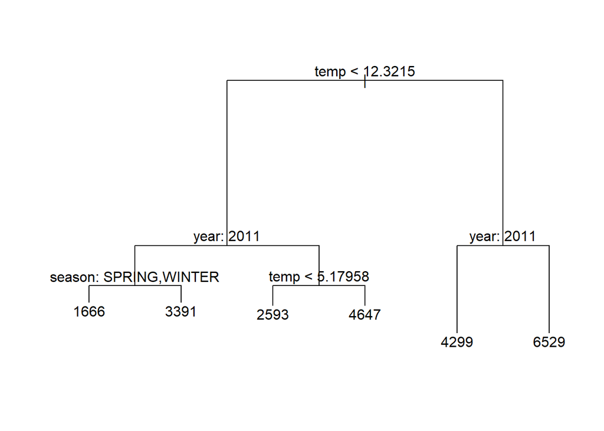

```r
prune.bike <- prune.tree(tree.bike, best = 6)
plot(prune.bike);text(prune.bike, pretty = 0)
```

As we mentioned before, we still can see effect caused by indicators such as temperature, year, season, while humidity seems to be less important after the tree was pruned.

Make predictions based on decision tree and see the distribution of y_hat and true value of bike sharing count.

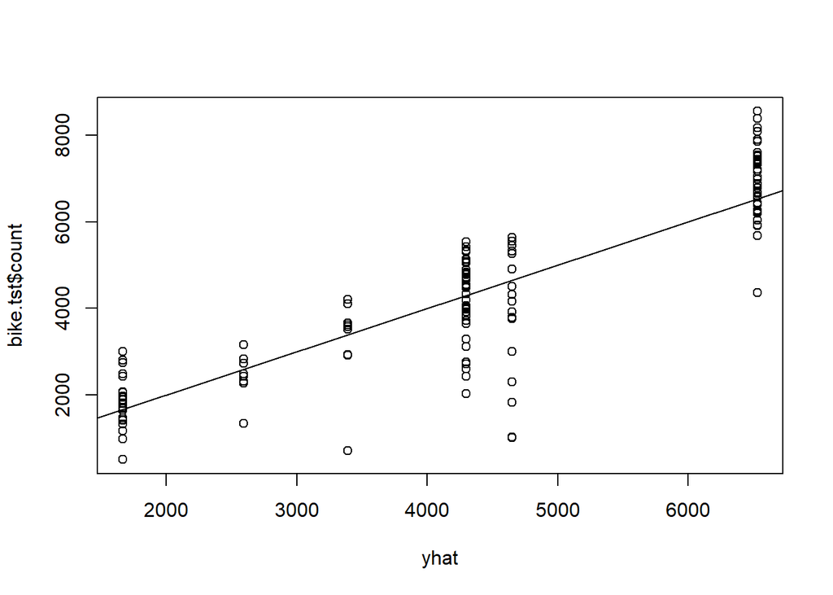

```r
yhat <- predict(prune.bike, newdata = bike.tst)
plot(yhat, bike.tst$count);abline(0, 1)
```

Calculate MSE of decision tree.

```r
MSE_tree<-mean((yhat - bike.tst$count)^2)
MSE_tree
```

```
## [1] 937345.1
```

### Model2: Random Forest & Bagging

The second model is random forest and bagging, and decide the best parameter by 5-fold cross validation. #### Random Forest Fit random forest model and view the cv error list.

```r
k <- 5
n <- nrow(bike.tr)
set.seed(1)
folds <- sample(rep(1:k, length = n))
cv.errors <- matrix(NA, k, 8, dimnames = list(NULL, paste(1:8)))
for (j in 1:k) {
  for (i in 1:8) {
  best.fit<-randomForest(count ~ ., data = bike.tr[folds != j,] ,mtry = i, importance=TRUE)
  pred <- predict(best.fit, bike.tr[folds == j, ])
cv.errors[j, i] <- mean((bike.tr$count[folds == j] - pred)^2)
}
}
mean.cv.errors <- apply(cv.errors, 2, mean)
mean.cv.errors
```

```
##        1        2        3        4        5        6        7        8
## 836897.6 488798.3 470669.4 487226.4 494866.9 511806.9 522453.3 520649.0
```

```r
which.min(mean.cv.errors)
```

```
## 3
## 3
```

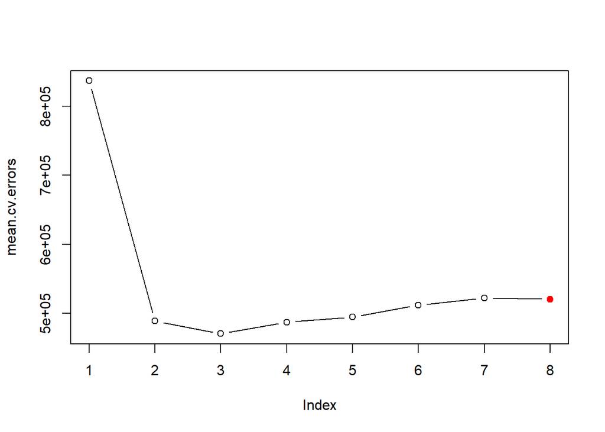

```r
plot(mean.cv.errors, type = "b");points(8, mean.cv.errors[8], col = "red", cex = 1.5, pch = 20)
```

#### Best random forest model

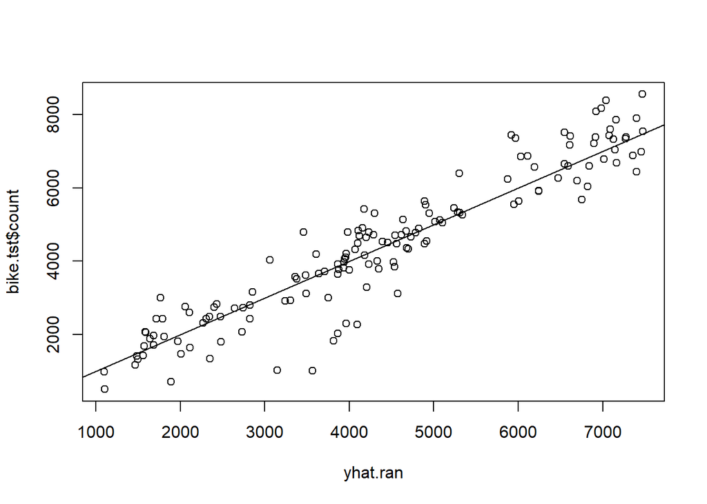

```r
set.seed(1)
bike.ran<-randomForest(count ~ ., data = bike.tr ,mtry = 5, importance=TRUE)
yhat.ran <- predict(bike.ran, newdata = bike.tst)
plot(yhat.ran, bike.tst$count);abline(0, 1)
```

The above graph shows the distribution of predicted y_hat and true value of bike sharing count. Compared to decision tree, we can see that relationship between y_hat and real count value fits the line with slope=1 better.

Calculate MSE for the best random forest model.

```r
MSE_ran<-mean((yhat.ran - bike.tst$count)^2)
MSE_ran
```

```
## [1] 475020
```

And the MSE of random forest has significantly decrease, too.

Take a look at importance of each indicator in random forest model.

```r
importance(bike.ran)
```

```
##               %IncMSE IncNodePurity
## year       170.834024     624473021
## season      59.153856     257028922
## specialday   8.209126      20441926
## weather     24.185099      54378811
## temp        97.521761     902663110
## hum         47.252230     161239348
## windspeed   22.713808      97828195
```

For the first measurement, “year” variable contribute to the accuracy in predictions the most; on the other hand, split over “temp” variable results in the most decrease in node impurity, averaged over all trees. So we can view the these two variables as important input indicators for predicting bike sharing counts.

#### Bagging

Next, fit training set into bagging model(mtry=8), and plot the distribution between y_hat and real count values.

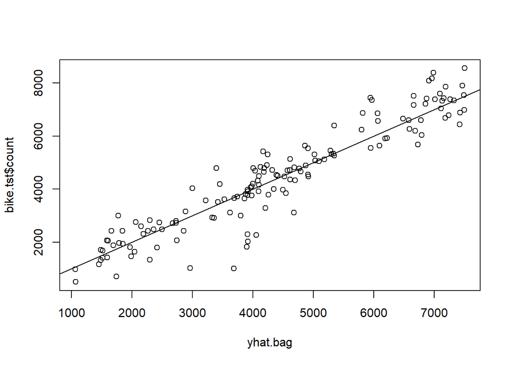

```r
set.seed(1)
bike.bag<-randomForest(count ~ ., data = bike.tr ,mtry = 8, importance=TRUE)
yhat.bag <- predict(bike.bag, newdata = bike.tst)
plot(yhat.bag, bike.tst$count);abline(0, 1)
```

The relationship between y_hat predicted by bagging model also roughly follow the pattern of line with slope=1.

And calculate MSE of bagging model.

```r
MSE_bag<-mean((yhat.bag - bike.tst$count)^2)
MSE_bag
```

```
## [1] 479506.8
```

MSE for bagging is quite close to the best size random forest, while random forest still performs a little bit better.

```r
importance(bike.bag)
```

```
##               %IncMSE IncNodePurity
## year       173.864830     624552624
## season      76.700717     180435223
## specialday   6.216681      20985891
## weather     21.082307      43292396
## temp       118.287754    1011923332
## hum         52.099414     158373898
## windspeed   23.950981      89583828
```

AS we mentioned above, coefficients importance of bagging is quite similar to that of random forest.

### Model3: Boosting

The next tree model comes to boosting. Similarly, using 5-fold to decide the best parameter of boosting model.

```r
k <- 5
n <- nrow(bike.tr)
set.seed(1)
folds <- sample(rep(1:k, length = n))
cv.errors <- matrix(NA, k, 5, dimnames = list(NULL, paste(1:5)))
for (j in 1:k) {
  for (i in 1:5) {
  best.fit <- gbm(count ~ ., data =bike.tr[folds!=j,],
    distribution = "gaussian", n.trees = 1000,
    interaction.depth = 5,shrinkage = i*0.01)
  pred <- predict(best.fit, bike.tr[folds == j, ])
cv.errors[j, i] <- mean((bike.tr$count[folds == j] - pred)^2)
}
}
mean.cv.errors <- apply(cv.errors, 2, mean)
mean.cv.errors
```

```
##        1        2        3        4        5
## 429646.1 427146.0 433656.2 431755.4 441971.0
```

```r
which.min(mean.cv.errors)
```

```
## 2
## 2
```

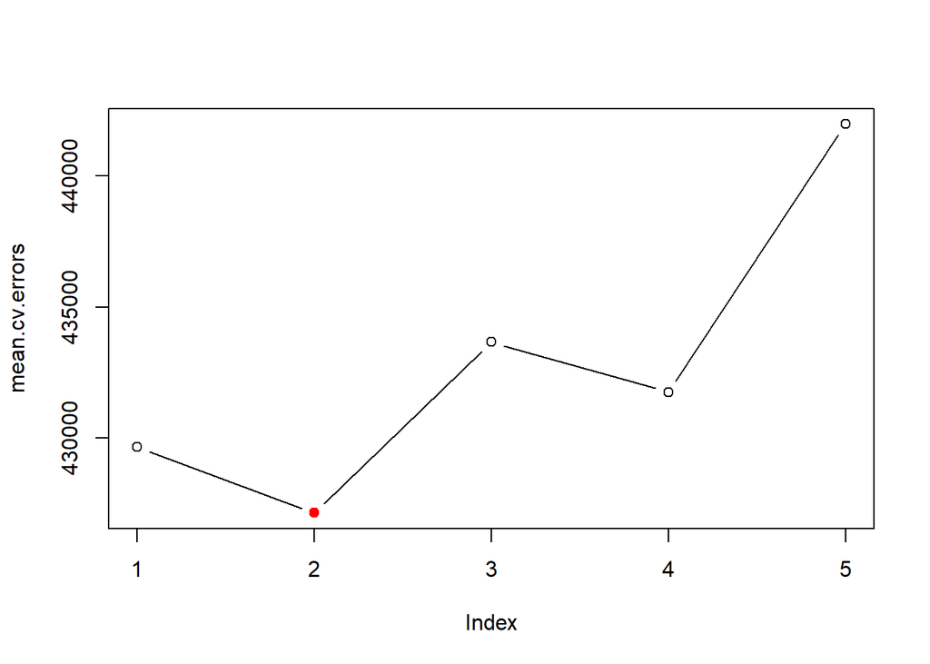

```r
plot(mean.cv.errors, type = "b");points(2, mean.cv.errors[2], col = "red", cex = 1.5, pch = 20)
```

By the above graph, we can see that the best shrinkage value appear at 0.02.

Then we fit boosting model based on the best shrinkage value.

```r
set.seed(1)
bike.boost<-gbm(count ~ ., data =bike.tr,
    distribution = "gaussian", n.trees = 1000,
    interaction.depth = 5,shrinkage = 0.02)
yhat.boost<-predict(bike.boost,bike.tst)
```

```r
MSE_boost<-mean((yhat.boost - bike.tst$count)^2)
MSE_boost
```

```
## [1] 500630
```

MSE of boosting model is a little bit higher than random forest and bagging. While overall speaking, these three model averagely own better performance than single decision tree.

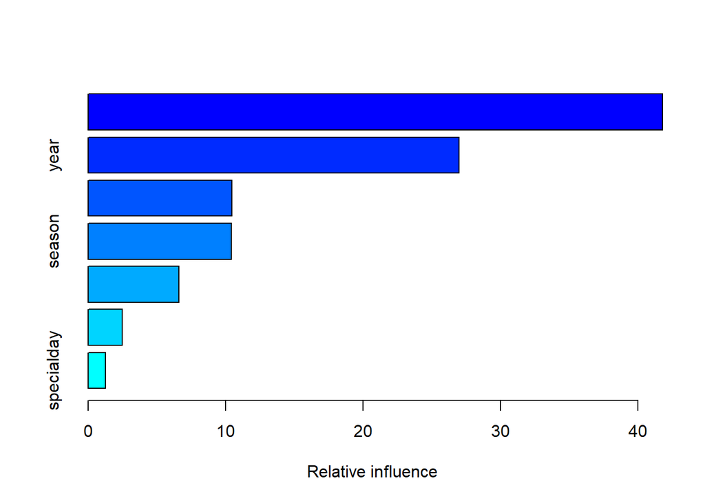

```
##                   var   rel.inf
## temp             temp 41.770270
## year             year 26.984373
## hum               hum 10.445959
## season         season 10.421551
## windspeed   windspeed  6.608457
## weather       weather  2.494397
## specialday specialday  1.274992
```

```r
summary(bike.boost)
```

By summary of the boosting model, we can view the importance order of each coefficient, and the “year”&“temperature” still remain the most important role in the model.

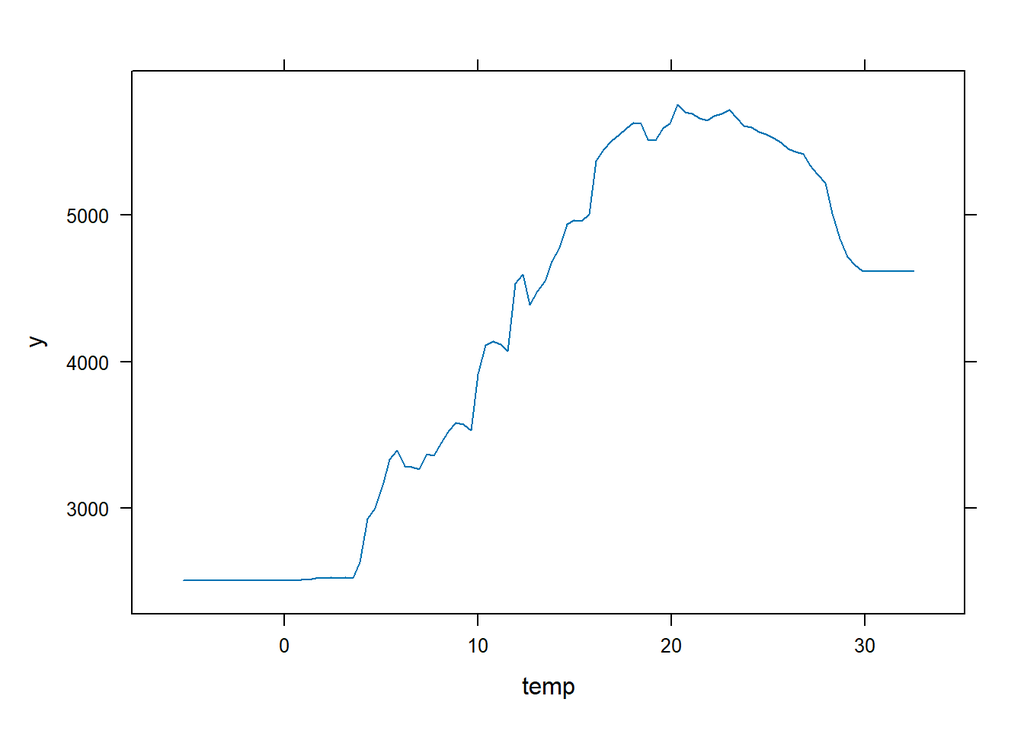

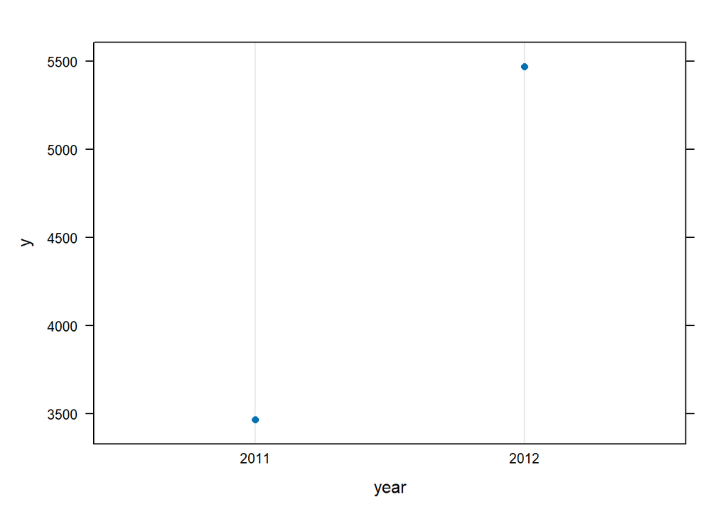

```r
par(mfrow=c(1,2))
plot(bike.boost, i = "temp");plot(bike.boost,i="year")
```

By the partial dependence plots for these two variables, we can see that bike sharing count increases with temperature first, and decreases as temperature reach certain level. As for the year variable, bike sharing count appears to be higher in 2012.

### Model4: Linear Regression

First, fit linear regression into all variables,and calculate its MSE.

```r
#Regression with all variable
bike.lm<-lm(count~.,data=bike.tr)
yhat.reg<-predict(bike.lm,bike.tst)
MSE_reg<-mean((yhat.reg - bike.tst$count)^2)
MSE_reg
```

```
## [1] 779868.5
```

The MSE of regression model with all variables don’t seem to have ideal performance compared to the above tree based model. Hence, we’ll do some adjustments in the following steps.

First, define a prediction function to make prediction based on forward selection

```r
predict.regsubsets <- function(object, newdata, id, ...) {
  form <- as.formula(object$call[[2]])
  mat <- model.matrix(form, newdata)
  coefi <- coef(object, id = id)
  xvars <- names(coefi)
  mat[, xvars] %*% coefi
 }
```

Pick forward selection as the variable selection method, and use 5-fold cross validation to select the best variable set.

```r
k <- 5
n <- nrow(bike.tr)
set.seed(1)
folds <- sample(rep(1:k, length = n))
cv.errors <- matrix(NA, k, 8, dimnames = list(NULL, paste(1:8)))

for (j in 1:k) {
best.fit <- regsubsets(count ~ ., data = bike.tr[folds != j, ], nvmax = 8
, method = "forward")
for (i in 1:8) {
pred <- predict(best.fit, bike.tr[folds == j, ], id = i)
cv.errors[j, i] <- mean((bike.tr$count[folds == j] - pred)^2)
}
}
mean.cv.errors <- apply(cv.errors, 2, mean)
mean.cv.errors
```

```
##         1         2         3         4         5         6         7         8
## 2243295.2 1166502.5  944763.5  833462.1  749131.7  711653.0  713616.8  702563.6
```

```r
which.min(mean.cv.errors)
```

```
## 8
## 8
```

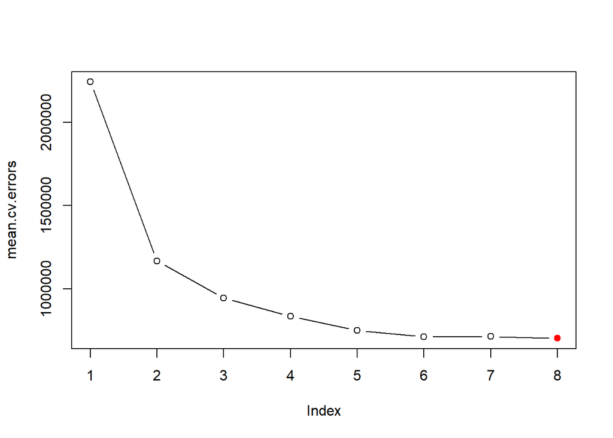

```r
plot(mean.cv.errors, type = "b");points(8, mean.cv.errors[8], col = "red", cex = 1.5, pch = 20)
```

From the above graph, we can see that cv error starts to converge after id=5, and reach minimum when id=8; therefore, we choose 5 as the best id number.

Fit the best id number into linear regression.

```r
bike.forlm<-regsubsets(count ~ ., data = bike.tr, nvmax = 8
, method = "forward")
summary(bike.forlm)
```

```
## Subset selection object
## Call: regsubsets.formula(count ~ ., data = bike.tr, nvmax = 8, method = "forward")
## 11 Variables  (and intercept)
##                        Forced in Forced out
## year2012                   FALSE      FALSE
## seasonSPRING               FALSE      FALSE
## seasonSUMMER               FALSE      FALSE
## seasonWINTER               FALSE      FALSE
## specialdayWEEKEND          FALSE      FALSE
## specialdayWORKING DAY      FALSE      FALSE
## weatherMISTY               FALSE      FALSE
## weatherRAIN/SNOW/STORM     FALSE      FALSE
## temp                       FALSE      FALSE
## hum                        FALSE      FALSE
## windspeed                  FALSE      FALSE
## 1 subsets of each size up to 8
## Selection Algorithm: forward
##          year2012 seasonSPRING seasonSUMMER seasonWINTER specialdayWEEKEND
## 1  ( 1 ) " "      " "          " "          " "          " "
## 2  ( 1 ) "*"      " "          " "          " "          " "
## 3  ( 1 ) "*"      " "          " "          "*"          " "
## 4  ( 1 ) "*"      " "          " "          "*"          " "
## 5  ( 1 ) "*"      " "          " "          "*"          " "
## 6  ( 1 ) "*"      " "          " "          "*"          " "
## 7  ( 1 ) "*"      " "          " "          "*"          " "
## 8  ( 1 ) "*"      " "          "*"          "*"          " "
##          specialdayWORKING DAY weatherMISTY weatherRAIN/SNOW/STORM temp hum
## 1  ( 1 ) " "                   " "          " "                    "*"  " "
## 2  ( 1 ) " "                   " "          " "                    "*"  " "
## 3  ( 1 ) " "                   " "          " "                    "*"  " "
## 4  ( 1 ) " "                   " "          "*"                    "*"  " "
## 5  ( 1 ) " "                   "*"          "*"                    "*"  " "
## 6  ( 1 ) " "                   "*"          "*"                    "*"  " "
## 7  ( 1 ) " "                   "*"          "*"                    "*"  "*"
## 8  ( 1 ) " "                   "*"          "*"                    "*"  "*"
##          windspeed
## 1  ( 1 ) " "
## 2  ( 1 ) " "
## 3  ( 1 ) " "
## 4  ( 1 ) " "
## 5  ( 1 ) " "
## 6  ( 1 ) "*"
## 7  ( 1 ) "*"
## 8  ( 1 ) "*"
```

```r
yhat.forlm<-predict(bike.forlm,bike.tst,id=5)
MSE_forlm<-mean((yhat.forlm - bike.tst$count)^2)
MSE_forlm
```

```
## [1] 867251.3
```

While the MSE result of regression model after forward selection get even worse. Therefore, we’ll do some nonlinearity model adjustment just as we observed in EDA.

Coefficients of the best linear model.

```r
coef.names = names(coef(bike.forlm, id = 5))[-1]
coef.names
```

```
## [1] "year2012"               "seasonWINTER"           "weatherMISTY"
## [4] "weatherRAIN/SNOW/STORM" "temp"
```

The above figure shows variable produced by forward selection , and important variables we mentioned before do appear on it, which correspond to the previous models.

### Model5: Nonlinear Regression

For nonlinear regression, we fit five different degrees of models for each quantitative variable “temp”, “hum”, “windspeed” sequentially, and compare the simpler model to the more complex model by anova test.

```r
#Variable 1: temp
fit.1 <- lm(count ~ temp, data = bike_new)
fit.2 <- lm(count ~ poly(temp, 2), data = bike_new)
fit.3 <- lm(count ~ poly(temp, 3), data = bike_new)
fit.4 <- lm(count ~ poly(temp, 4), data = bike_new)
fit.5 <- lm(count ~ poly(temp, 5), data = bike_new)
anova(fit.1, fit.2, fit.3, fit.4, fit.5)
```

```
## Analysis of Variance Table
##
## Model 1: count ~ temp
## Model 2: count ~ poly(temp, 2)
## Model 3: count ~ poly(temp, 3)
## Model 4: count ~ poly(temp, 4)
## Model 5: count ~ poly(temp, 5)
##   Res.Df        RSS Df Sum of Sq       F    Pr(>F)
## 1    729 1660846807
## 2    728 1498035413  1 162811394 80.2132 < 2.2e-16 ***
## 3    727 1472082143  1  25953270 12.7865 0.0003723 ***
## 4    726 1472044792  1     37351  0.0184 0.8921329
## 5    725 1471556343  1    488449  0.2406 0.6238876
## ---
## Signif. codes:  0 '***' 0.001 '**' 0.01 '*' 0.05 '.' 0.1 ' ' 1
```

From the anova result, we can see that degree 3 is sufficient to fit pattern of “temp” variable.

```r
#Variable 2: hum
fit.1 <- lm(count ~ hum, data = bike_new)
fit.2 <- lm(count ~ poly(hum, 2), data = bike_new)
fit.3 <- lm(count ~ poly(hum, 3), data = bike_new)
fit.4 <- lm(count ~ poly(hum, 4), data = bike_new)
fit.5 <- lm(count ~ poly(hum, 5), data = bike_new)
anova(fit.1, fit.2, fit.3, fit.4, fit.5)
```

```
## Analysis of Variance Table
##
## Model 1: count ~ hum
## Model 2: count ~ poly(hum, 2)
## Model 3: count ~ poly(hum, 3)
## Model 4: count ~ poly(hum, 4)
## Model 5: count ~ poly(hum, 5)
##   Res.Df        RSS Df Sum of Sq       F    Pr(>F)
## 1    729 2711778019
## 2    728 2525458259  1 186319761 54.0402 5.314e-13 ***
## 3    727 2508548832  1  16909427  4.9044    0.0271 *
## 4    726 2507755507  1    793324  0.2301    0.6316
## 5    725 2499652252  1   8103255  2.3503    0.1257
## ---
## Signif. codes:  0 '***' 0.001 '**' 0.01 '*' 0.05 '.' 0.1 ' ' 1
```

```r
#Variable 3: windspeed
fit.1 <- lm(count ~ windspeed, data = bike_new)
fit.2 <- lm(count ~ poly(windspeed, 2), data = bike_new)
fit.3 <- lm(count ~ poly(windspeed, 3), data = bike_new)
fit.4 <- lm(count ~ poly(windspeed, 4), data = bike_new)
fit.5 <- lm(count ~ poly(windspeed, 5), data = bike_new)
anova(fit.1, fit.2, fit.3, fit.4, fit.5)
```

```
## Analysis of Variance Table
##
## Model 1: count ~ windspeed
## Model 2: count ~ poly(windspeed, 2)
## Model 3: count ~ poly(windspeed, 3)
## Model 4: count ~ poly(windspeed, 4)
## Model 5: count ~ poly(windspeed, 5)
##   Res.Df        RSS Df Sum of Sq      F Pr(>F)
## 1    729 2588829836
## 2    728 2581049365  1   7780471 2.1943 0.1390
## 3    727 2577677127  1   3372238 0.9511 0.3298
## 4    726 2574509895  1   3167232 0.8932 0.3449
## 5    725 2570683117  1   3826778 1.0793 0.2992
```

However, for the “windspeed” variable, the results appear to be nonsignificant, we’ll try on other nonlinear method to deal with it later.

Then fit a nonlinear regression with the above adjustment we tested before.

```r
bike.nonlinlm <- lm(count ~ year+season+specialday+weather+poly(temp,3) +poly(hum,2)+windspeed, data = bike.tr)
summary(bike.nonlinlm)
```

```
##
## Call:
## lm(formula = count ~ year + season + specialday + weather + poly(temp,
##     3) + poly(hum, 2) + windspeed, data = bike.tr)
##
## Residuals:
##      Min       1Q   Median       3Q      Max
## -3037.31  -330.46    46.41   402.09  2719.52
##
## Coefficients:
##                          Estimate Std. Error t value Pr(>|t|)
## (Intercept)              4219.019    183.028  23.051  < 2e-16 ***
## year2012                 1960.600     56.312  34.816  < 2e-16 ***
## seasonSPRING             -433.685     90.419  -4.796 2.07e-06 ***
## seasonSUMMER             -213.066    122.845  -1.734 0.083383 .
## seasonWINTER            -1213.004     91.579 -13.245  < 2e-16 ***
## specialdayWEEKEND         505.748    165.634   3.053 0.002368 **
## specialdayWORKING DAY     572.026    161.125   3.550 0.000417 ***
## weatherMISTY             -327.049     75.239  -4.347 1.64e-05 ***
## weatherRAIN/SNOW/STORM  -1634.237    227.680  -7.178 2.22e-12 ***
## poly(temp, 3)1          21199.316   1254.958  16.892  < 2e-16 ***
## poly(temp, 3)2         -10293.095    820.261 -12.549  < 2e-16 ***
## poly(temp, 3)3          -7172.915    690.892 -10.382  < 2e-16 ***
## poly(hum, 2)1           -8487.896    934.575  -9.082  < 2e-16 ***
## poly(hum, 2)2           -4136.454    771.285  -5.363 1.19e-07 ***
## windspeed                 -49.061      5.675  -8.646  < 2e-16 ***
## ---
## Signif. codes:  0 '***' 0.001 '**' 0.01 '*' 0.05 '.' 0.1 ' ' 1
##
## Residual standard error: 665.8 on 569 degrees of freedom
## Multiple R-squared:  0.8828, Adjusted R-squared:  0.8799
## F-statistic: 306.2 on 14 and 569 DF,  p-value: < 2.2e-16
```

It seems like most variables of the nonlinear variables appear to be significant, and let’s make predictions on it.

```r
yhat.nonlinlm<-predict(bike.nonlinlm,bike.tst)
MSE_nonlinlm<-mean((yhat.nonlinlm - bike.tst$count)^2)
MSE_nonlinlm
```

```
## [1] 516091.5
```

The MSE for the nonlinear regression has improved a lot from the linear regression.

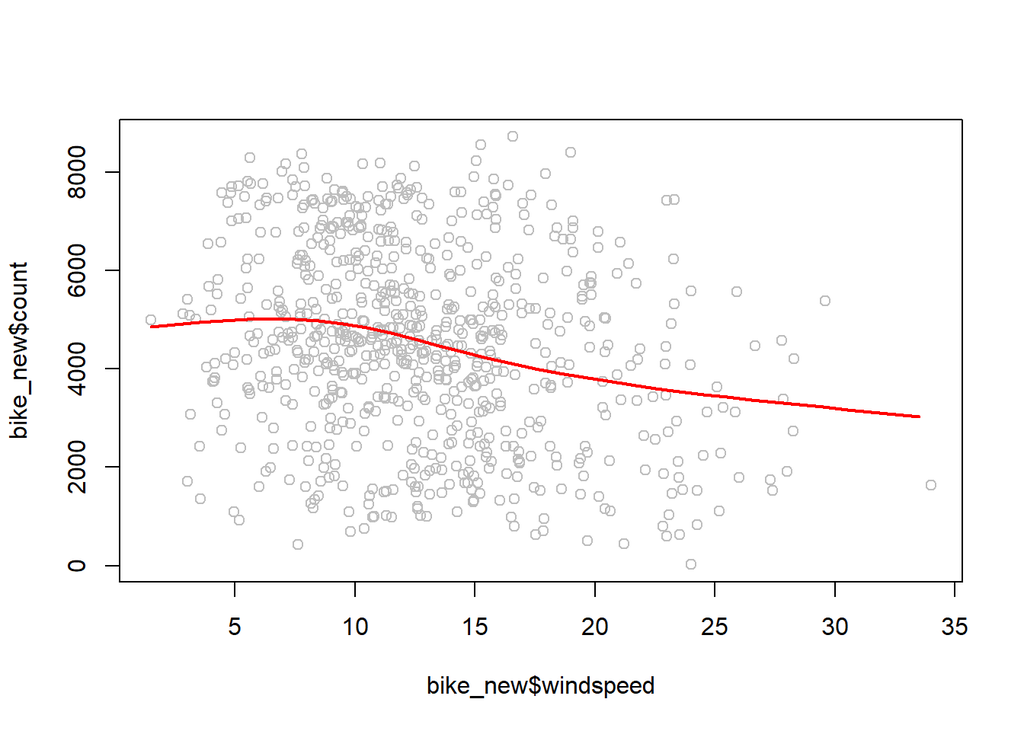

```r
windspeedlims <- range(bike_new$windspeed)
windspeed.grid <- seq(from = windspeedlims[1], to = windspeedlims[2])
fit.ns <- lm(count ~ ns(windspeed, df = 3), data = bike.tr)
pred <- predict(fit.ns, newdata =list(windspeed=windspeed.grid),se = T)
plot(bike_new$windspeed, bike_new$count, col = "gray");lines(windspeed.grid, pred$fit, col = "red", lwd = 2)
```

Fit the natural spline to variable “windspeded”, and observe the relationship between ns line and the real points.

```r
bike.nonlinlm2 <- lm(count ~ year+season+specialday+weather+poly(temp,3) +poly(hum,2)+ns(windspeed,df=3), data = bike.tr)
```

Finally, fit a new nonlinear regression model with natural spline.

```r
yhat.nonlinlm2<-predict(bike.nonlinlm2,bike.tst)
MSE_nonlinlm2<-mean((yhat.nonlinlm2 - bike.tst$count)^2)
MSE_nonlinlm2
```

```
## [1] 498662.2
```

Calculate its MSE, and we can see that it improves compared to the first nonlinear model.

```r
summary(bike.nonlinlm2)
```

```
##
## Call:
## lm(formula = count ~ year + season + specialday + weather + poly(temp,
##     3) + poly(hum, 2) + ns(windspeed, df = 3), data = bike.tr)
##
## Residuals:
##      Min       1Q   Median       3Q      Max
## -3042.46  -324.45    46.32   407.24  2745.81
##
## Coefficients:
##                         Estimate Std. Error t value Pr(>|t|)
## (Intercept)              4260.44     239.12  17.817  < 2e-16 ***
## year2012                 1976.18      56.68  34.865  < 2e-16 ***
## seasonSPRING             -435.04      91.35  -4.762 2.44e-06 ***
## seasonSUMMER             -216.92     122.84  -1.766 0.077963 .
## seasonWINTER            -1197.77      92.08 -13.007  < 2e-16 ***
## specialdayWEEKEND         523.68     165.54   3.164 0.001642 **
## specialdayWORKING DAY     594.97     161.17   3.692 0.000244 ***
## weatherMISTY             -332.92      75.15  -4.430 1.13e-05 ***
## weatherRAIN/SNOW/STORM  -1636.69     227.20  -7.204 1.88e-12 ***
## poly(temp, 3)1          21350.69    1256.58  16.991  < 2e-16 ***
## poly(temp, 3)2         -10214.43     823.46 -12.404  < 2e-16 ***
## poly(temp, 3)3          -7193.83     691.33 -10.406  < 2e-16 ***
## poly(hum, 2)1           -8393.09     933.91  -8.987  < 2e-16 ***
## poly(hum, 2)2           -4110.37     770.43  -5.335 1.38e-07 ***
## ns(windspeed, df = 3)1   -480.61     136.59  -3.519 0.000469 ***
## ns(windspeed, df = 3)2  -1909.44     416.24  -4.587 5.53e-06 ***
## ns(windspeed, df = 3)3  -1552.45     215.26  -7.212 1.78e-12 ***
## ---
## Signif. codes:  0 '***' 0.001 '**' 0.01 '*' 0.05 '.' 0.1 ' ' 1
##
## Residual standard error: 664.4 on 567 degrees of freedom
## Multiple R-squared:  0.8837, Adjusted R-squared:  0.8805
## F-statistic: 269.4 on 16 and 567 DF,  p-value: < 2.2e-16
```

Take a deeper look at coefficients of the linear regression with best performance. For the “weather” variable, it turns out that the class “MISTY” and “RAIN/SNOW/STORM” appear to be significant in the regression model. They both cause negative effect to the bike sharing count, and the effect caused by “RAIN/SNOW/STORM” is more severe based on the amount of coefficient. As for other weather related variables such as temperature, humidity, windspeed, most of them have negative effect on the target variable as they increase. It is worth to mention that only coefficient of poly(temp, 3)1 is positive, and the we speculate reason behind is that bike sharing count increase as temperature increase originally, while as temperature reaches certain level, the bike demand starts to drop, which has been shown on the dependence plots for “temp” variable.

### Comparison of Model Performance

```r
data.frame(MSE_tree,MSE_ran,MSE_boost,MSE_reg,MSE_forlm,MSE_nonlinlm2)
```

```
##   MSE_tree MSE_ran MSE_boost  MSE_reg MSE_forlm MSE_nonlinlm2
## 1 937345.1  475020    500630 779868.5  867251.3      498662.2
```

To conclude, for the model performance, tree based model such as random forest and boosting share similar MSE, and the regression model performs not well when it’s linear, while after adding some nonlinear terms, the model performance can reach that of tree based model.

## Problem 2: Airline Customer Satisfaction

This dataset contains an airline passenger satisfaction survey. The data collect the demographic information about the customers, their feedback regarding the flight experiences and some flight information.

The goal of the analysis has two folds:

- Find a good model for the classification of customer satisfaction, and summarize the performance.
- Identify the important aspects of the flight experience related to customer satisfaction (or dis-satisfaction). Based on your findings, give some specific suggestions (provided with the data evidence) to the airline company for achieving a higher customer satisfaction.
- Add some noise factors (both continuous variable and categorical variable) in your data set (call these added variables z1-z?), and check the ranking of variable importance of these z-variables relative to the original meaningful input variables. Make your comments regarding this experiment.

More data descriptions can be found at https://www.kaggle.com/teejmahal20/airline-passenger-satisfaction

### Read data

```r
survey <- read.csv(file="airline.csv") #read data
head(survey)
```

```
##       id Gender     Customer.Type Age  Type.of.Travel    Class Flight.Distance
## 1  70172   Male    Loyal Customer  13 Personal Travel Eco Plus             460
## 2   5047   Male disloyal Customer  25 Business travel Business             235
## 3 110028 Female    Loyal Customer  26 Business travel Business            1142
## 4  24026 Female    Loyal Customer  25 Business travel Business             562
## 5 119299   Male    Loyal Customer  61 Business travel Business             214
## 6 111157 Female    Loyal Customer  26 Personal Travel      Eco            1180
##   Inflight.wifi.service Departure.Arrival.time.convenient
## 1                     3                                 4
## 2                     3                                 2
## 3                     2                                 2
## 4                     2                                 5
## 5                     3                                 3
## 6                     3                                 4
##   Ease.of.Online.booking Gate.location Food.and.drink Online.boarding
```

[output cut: 27 more lines]

```r
survey1 <- na.omit(survey) #remove missing data
survey1<-survey1[,-1]
```

### Data frame adjustment

Convert categorical variable into factor, and satisfied to be 1 and neutral or dissatisfied to be 0.

```r
survey1$Gender<-factor(survey1$Gender)
survey1$Customer.Type<-factor(survey1$Customer.Type)
survey1$Type.of.Travel<-factor(survey1$Type.of.Travel)
survey1$Class<-factor(survey1$Class)
survey1$Inflight.wifi.service <- as.factor(survey1$Inflight.wifi.service)
survey1$Departure.Arrival.time.convenient  <-as.factor(survey1$Departure.Arrival.time.convenient)
survey1$Ease.of.Online.booking <- as.factor(survey1$Ease.of.Online.booking)
survey1$Gate.location <- as.factor(survey1$Gate.location)
survey1$Food.and.drink <- as.factor(survey1$Food.and.drink)
survey1$Online.boarding <- as.factor(survey1$Online.boarding)
survey1$Seat.comfort <- as.factor(survey1$Seat.comfort)
survey1$Leg.room.service <- as.factor(survey1$Leg.room.service)
survey1$Inflight.entertainment <- as.factor(survey1$Inflight.entertainment)
survey1$On.board.service <- as.factor(survey1$On.board.service)
survey1$Checkin.service <- as.factor(survey1$Checkin.service)
survey1$Inflight.service <- as.factor(survey1$Inflight.service)
survey1$Cleanliness <- as.factor(survey1$Cleanliness)
survey1$Baggage.handling <- as.factor(survey1$Baggage.handling)
survey1$satisfaction <- ifelse(survey1$satisfaction=="satisfied",1,0)
survey1$satisfaction <- factor(survey1$satisfaction, levels = c(0, 1))
```

### EDA

Observe structure of the data set.

```r
summary(survey1)
```

```
##     Gender                Customer.Type        Age
##  Female:52576   disloyal Customer:18932   Min.   : 7.00
##  Male  :51018   Loyal Customer   :84662   1st Qu.:27.00
##                                           Median :40.00
##                                           Mean   :39.38
##                                           3rd Qu.:51.00
##                                           Max.   :85.00
##          Type.of.Travel       Class       Flight.Distance Inflight.wifi.service
##  Business travel:71465   Business:49533   Min.   :  31    0: 3096
##  Personal Travel:32129   Eco     :46593   1st Qu.: 414    1:17781
##                          Eco Plus: 7468   Median : 842    2:25755
##                                           Mean   :1189    3:25789
##                                           3rd Qu.:1743    4:19737
##                                           Max.   :4983    5:11436
##  Departure.Arrival.time.convenient Ease.of.Online.booking Gate.location
##  0: 5290                           0: 4473                0:    1
##  1:15452                           1:17466                1:17511
##  2:17142                           2:23962                2:19396
##  3:17903                           3:24370                3:28489
##  4:25474                           4:19508                4:24353
##  5:22333                           5:13815                5:13844
##  Food.and.drink Online.boarding Seat.comfort Inflight.entertainment
##  0:  105        0: 2420         0:    1      0:   14
##  1:12800        1:10658         1:12031      1:12441
##  2:21918        2:17449         2:14846      2:17579
##  3:22238        3:21744         3:18641      3:19080
##  4:24294        4:30671         4:31682      4:29335
##  5:22239        5:20652         5:26393      5:25145
##  On.board.service Leg.room.service Baggage.handling Checkin.service
##  0:    3          0:  470          1: 7223          0:    1
##  1:11832          1:10310          2:11483          1:12852
##  2:14632          2:19469          3:20567          2:12854
##  3:22770          3:20042          4:37274          3:28356
##  4:30773          4:28704          5:27047          4:28975
##  5:23584          5:24599                           5:20556
##  Inflight.service Cleanliness Departure.Delay.in.Minutes
##  0:    3          0:   12     Min.   :   0.00
##  1: 7063          1:13276     1st Qu.:   0.00
##  2:11414          2:16081     Median :   0.00
##  3:20227          3:24506     Mean   :  14.75
##  4:37846          4:27100     3rd Qu.:  12.00
##  5:27041          5:22619     Max.   :1592.00
##  Arrival.Delay.in.Minutes satisfaction
##  Min.   :   0.00          0:58697
##  1st Qu.:   0.00          1:44897
##  Median :   0.00
##  Mean   :  15.18
##  3rd Qu.:  13.00
##  Max.   :1584.00
```

View distribution of target variable, it seems like there’s no unbalanced problem for target variable.

```r
table(survey1$satisfaction)
```

```
##
##     0     1
## 58697 44897
```

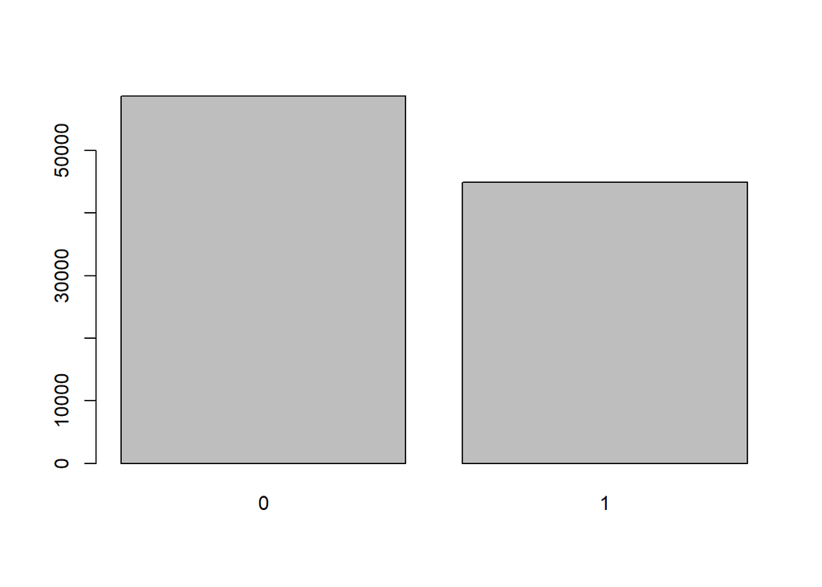

```r
barplot(table(survey1$satisfaction))
```

### Split training and testing set

```r
set.seed(2)
train <- sample(1:nrow(survey1), nrow(survey1)*0.8)
test<-(-train)
survey1.tr<-survey1[train,]
survey1.tst<-survey1[test,]
```

### Method 1: Lasso

Create dataframe for lasso.

```r
y <- survey1.tr$satisfaction
x <- data.matrix(survey1.tr[, -23])
```

Fit lasso regression into training set and select the best lambda value by cross validation(k=10) for the final model.

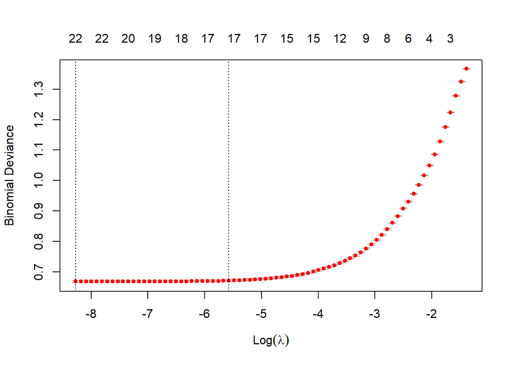

```r
# Find the best lambda using cross-validation
cv.lasso <- cv.glmnet(x, y, alpha = 1,family = "binomial")
plot(cv.lasso)
```

```r
# Fit the final model on the training data
survey1.lasso <- glmnet(x, y, alpha = 1, family = "binomial",
                lambda = cv.lasso$lambda.min)
```

Make predictions by lasso model on the test data.

```r
x.test <- data.matrix(survey1.tst[, -23])
probabilities <- predict(survey1.lasso,newx = x.test)
yhat.lasso <- ifelse(probabilities > 0.5, 1, 0)
```

View the resulting confusion matrix corresponding to the lasso predictions.

```r
pred_val<-yhat.lasso
true_val<-survey1.tst$satisfaction
table(pred_val,true_val)
```

```
##         true_val
## pred_val     0     1
##        0 11010  2002
##        1   649  7058
```

And the final accuracy rate of lasso is 0.87.

```r
acc_lasso<-mean(yhat.lasso == survey1.tst$satisfaction)
acc_lasso
```

```
## [1] 0.8720498
```

Take a look at coefficient produced by lasso regression model, and try to identify important predictors.

```r
coef_normal<-coef(survey1.lasso)
coef_normal
```

```
## 23 x 1 sparse Matrix of class "dgCMatrix"
##                                              s0
## (Intercept)                       -8.871675e+00
## Gender                             4.050631e-02
## Customer.Type                      2.061798e+00
## Age                               -7.264180e-03
## Type.of.Travel                    -2.815967e+00
## Class                             -5.392716e-01
## Flight.Distance                    4.666356e-07
## Inflight.wifi.service              3.912321e-01
## Departure.Arrival.time.convenient -1.245705e-01
## Ease.of.Online.booking            -1.430660e-01
## Gate.location                      2.386940e-02
## Food.and.drink                    -1.845152e-02
## Online.boarding                    6.126344e-01
## Seat.comfort                       6.627269e-02
## Inflight.entertainment             4.733301e-02
## On.board.service                   3.076067e-01
## Leg.room.service                   2.534743e-01
## Baggage.handling                   1.369687e-01
## Checkin.service                    3.303373e-01
## Inflight.service                   1.281466e-01
## Cleanliness                        2.229068e-01
## Departure.Delay.in.Minutes         2.500509e-03
## Arrival.Delay.in.Minutes          -7.208466e-03
```

For the coefficients for lasso model, we can first recognize “Customer.Type” and “Type.of.Travel” as the top 2 significant variables, the former has positive impact on the target variable, and the latter has negative impact on it. Subsequently, we can identify “Online.boarding” and “Class” as the significant indicators after “Customer.Type” and “Type.of.Travel”; similarly, the former has positive impact on the target variable, and the latter has negative impact on it.

### Method 2: Random Forest

We choose random forest as the second model, and use tuning function in random forest package to select the best mtry value.

```r
set.seed(2)
features <- setdiff(x = names(survey1.tr), y = "satisfaction")
tuneRF(x = survey1.tr[features], y = survey1.tr$satisfaction,mtryStart = 1)
```

```
## mtry = 1  OOB error = 7.18%
## Searching left ...
## Searching right ...
## mtry = 2     OOB error = 4.62%
## 0.3562426 0.05
## mtry = 4     OOB error = 4.04%
## 0.1258157 0.05
## mtry = 8     OOB error = 3.89%
## 0.03851896 0.05
```

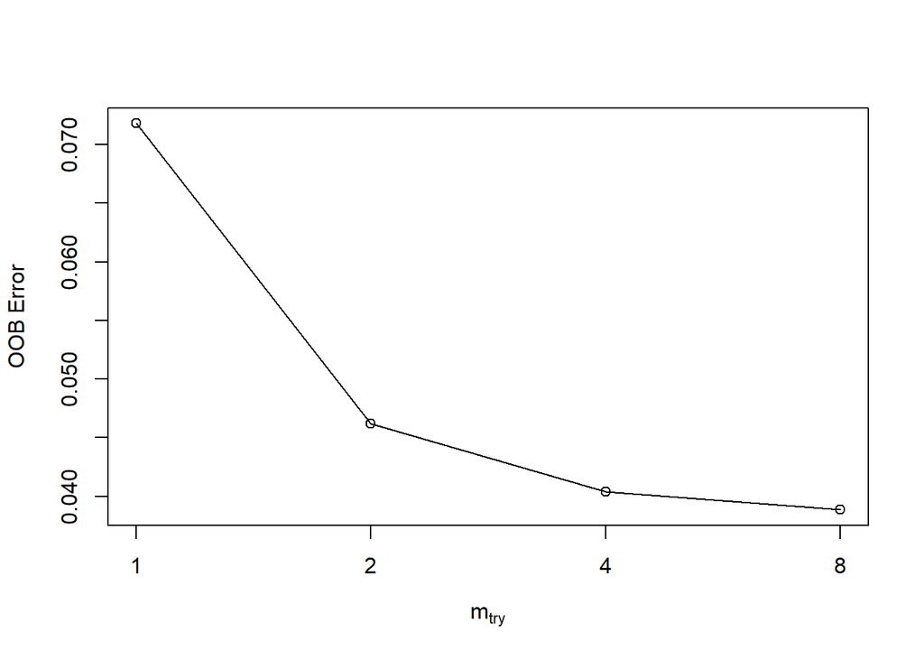

```
##       mtry   OOBError
## 1.OOB    1 0.07180694
## 2.OOB    2 0.04622624
## 4.OOB    4 0.04041026
## 8.OOB    8 0.03885370
```

By the above result, we can see that when mtry=8, it comes out with the lowest out of bag error rate.

Then, fit the selected mtry value into random forest model, and make predictions based on it.

```r
set.seed(2)
survey1.ran<-randomForest(satisfaction ~ ., data = survey1.tr ,mtry = 8, importance=TRUE)
yhat.ran <- predict(survey1.ran, newdata = survey1.tst)
```

View the confusion matrix of the prediction results.

```r
pred_val<-yhat.ran
true_val<-survey1.tst$satisfaction
table(pred_val,true_val)
```

```
##         true_val
## pred_val     0     1
##        0 11447   536
##        1   212  8524
```

The final accuracy rate of random forest is 0.96, which is relatively high compared to lasso regression.

```r
acc_ran<-mean(yhat.ran == survey1.tst$satisfaction)
acc_ran
```

```
## [1] 0.9638979
```

Take a look at coefficient produced by random forest model, and try to identify important predictors .

```r
importance(survey1.ran)
```

```
##                                            0         1 MeanDecreaseAccuracy
## Gender                              8.595039  10.82501             12.59378
## Customer.Type                      59.423674 129.10838            102.64074
## Age                                44.940079  57.11781             65.54528
## Type.of.Travel                     64.508412 169.19194            106.51165
## Class                              41.674165  45.69278             50.10259
## Flight.Distance                    35.264479  44.39245             52.99428
## Inflight.wifi.service             295.825801  68.70519            135.42782
## Departure.Arrival.time.convenient  35.317912  37.81800             43.29806
## Ease.of.Online.booking             30.688104  30.85351             36.88432
## Gate.location                      43.915661  34.22393             36.27844
## Food.and.drink                     18.348887  30.72205             31.06168
## Online.boarding                    91.379189  65.87008            106.07708
## Seat.comfort                       77.755096  54.15135             90.96736
## Inflight.entertainment             44.337706  40.69312             55.58447
## On.board.service                   58.907900  29.83147             58.55503
## Leg.room.service                   44.759551  33.68589             46.68091
## Baggage.handling                   83.965677  48.30965             97.12453
## Checkin.service                   100.020071  56.83555            115.88892
## Inflight.service                   76.918888  29.93736             76.86422
## Cleanliness                        56.423621  46.33526             74.38509
## Departure.Delay.in.Minutes         29.072072  13.03417             35.02985
## Arrival.Delay.in.Minutes           32.341287  35.41807             44.92749
##                                   MeanDecreaseGini
## Gender                                    97.90178
## Customer.Type                           1437.58342
## Age                                     1048.50986
## Type.of.Travel                          3637.29033
## Class                                   4715.88359
## Flight.Distance                          971.45028
## Inflight.wifi.service                   7152.25997
## Departure.Arrival.time.convenient        734.21120
## Ease.of.Online.booking                  1001.69410
## Gate.location                            760.77771
## Food.and.drink                           342.74723
## Online.boarding                         9136.46968
## Seat.comfort                            1315.47703
## Inflight.entertainment                  2251.24407
## On.board.service                         832.96413
## Leg.room.service                        1290.99802
## Baggage.handling                         867.65324
## Checkin.service                          854.84006
## Inflight.service                         837.71881
## Cleanliness                              660.98041
## Departure.Delay.in.Minutes               340.73823
## Arrival.Delay.in.Minutes                 381.62151
```

For the column “MeanDecreaseAccuracy”, “Inflight.wifi.service”,“Checkin.service” matters the most when it comes to accuracy, and “Customer.Type”, “Type.of.Travel”, “Online.boarding” these predictors are also significant in this aspect. On the other hand,for the decrease in value of gini loss function, “Online.boarding ,”Inflight.wifi.service” contribute the most, followed by indicators such as “Class”, “Type.of.Travel”. Hence, if we consider both aspects of importance, we’ll say “Inflight.wifi.service”,“Online.boarding”,“Type.of.Travel” are significant in both aspects. Specifically, “Online.boarding” contributes the most in “MeanDecreaseGini” column, and “Inflight.wifi.service” are the most important element in the “MeanDecreaseAccuracy”.

### Adding noise factor

Add four columns of noise factors(two qualitative, two quantitative) into the data set.

```r
set.seed(2)
survey1.tr.noise<-survey1.tr
survey1.tst.noise<-survey1.tst
survey1.tr.noise[,'z1']<-sample(1:100, nrow(survey1.tr),replace = T)
survey1.tst.noise[,'z1']<-sample(1:100, nrow(survey1.tst),replace = T)
survey1.tr.noise[,'z2']<-sample(1:50, nrow(survey1.tr),replace = T)
survey1.tst.noise[,'z2']<-sample(1:50, nrow(survey1.tst),replace = T)
survey1.tr.noise[,'z3']<-factor(sample(1:5, nrow(survey1.tr),replace = T))
survey1.tst.noise[,'z3']<-factor(sample(1:5, nrow(survey1.tst),replace = T))
survey1.tr.noise[,'z4']<-factor(sample(1:5, nrow(survey1.tr),replace = T))
survey1.tst.noise[,'z4']<-factor(sample(1:5, nrow(survey1.tst),replace = T))
```

### Rerun model 1: Lasso

Rerun the lasso regression model again.

```r
y <- survey1.tr.noise$satisfaction
x <- data.matrix(survey1.tr.noise[, -23])
```

Repeat the same steps before.

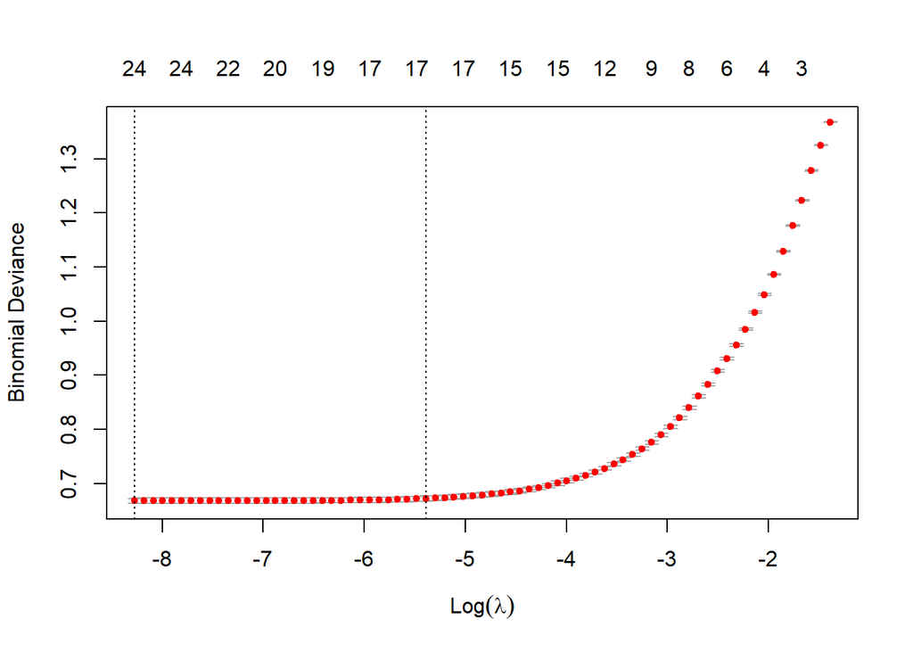

```r
cv.lasso.noise <- cv.glmnet(x, y, alpha = 1,family = "binomial")
plot(cv.lasso.noise)
```

```r
survey1.lasso.noise <- glmnet(x, y, alpha = 1, family = "binomial",
                lambda = cv.lasso.noise$lambda.min)
```

```r
x.test.noise <- data.matrix(survey1.tst.noise[, -23])
probabilities <- predict(survey1.lasso.noise,newx = x.test.noise)
yhat.lasso.noise <- ifelse(probabilities > 0.5, 1, 0)
```

The new accuracy rate is as below.

```r
# Model accuracy
acc_lasso.noise<-mean(yhat.lasso.noise == survey1.tst.noise$satisfaction)
acc_lasso.noise
```

```
## [1] 0.8714224
```

View the coefficient importance of the noise factor.

```r
#coefficient
coef_noise<-coef(survey1.lasso.noise)
coef_noise
```

```
## 27 x 1 sparse Matrix of class "dgCMatrix"
##                                              s0
## (Intercept)                       -8.915124e+00
## Gender                             4.051790e-02
## Customer.Type                      2.061386e+00
## Age                               -7.250919e-03
## Type.of.Travel                    -2.816033e+00
## Class                             -5.394043e-01
## Flight.Distance                    5.931729e-07
## Inflight.wifi.service              3.912508e-01
## Departure.Arrival.time.convenient -1.245786e-01
## Ease.of.Online.booking            -1.430480e-01
## Gate.location                      2.390674e-02
## Food.and.drink                    -1.849195e-02
## Online.boarding                    6.126542e-01
## Seat.comfort                       6.627112e-02
## Inflight.entertainment             4.749804e-02
## On.board.service                   3.074878e-01
## Leg.room.service                   2.534572e-01
## Baggage.handling                   1.368861e-01
## Checkin.service                    3.303503e-01
## Inflight.service                   1.281903e-01
## Cleanliness                        2.228469e-01
## Departure.Delay.in.Minutes         2.496276e-03
## Arrival.Delay.in.Minutes          -7.202590e-03
## z1                                 2.367070e-04
## z2                                 .
## z3                                 1.058152e-02
## z4                                 .
```

Apparently, we can see that the noise factors we add don’t have any significant influence on the lasso regression model, some coefficient values are even too small to show.

### Rerun model 2: Random Forest again

Repeat the same steps with the noise data in random forest model.

```r
set.seed(2)
features <- setdiff(x = names(survey1.tr.noise), y = "satisfaction")
tuneRF(x = survey1.tr.noise[features], y = survey1.tr.noise$satisfaction,mtryStart = 1)
```

```
## mtry = 1  OOB error = 7.4%
## Searching left ...
## Searching right ...
## mtry = 2     OOB error = 5.09%
## 0.3118578 0.05
## mtry = 4     OOB error = 4.33%
## 0.1500356 0.05
## mtry = 8     OOB error = 3.92%
## 0.09509202 0.05
## mtry = 16    OOB error = 3.81%
## 0.02742681 0.05
```

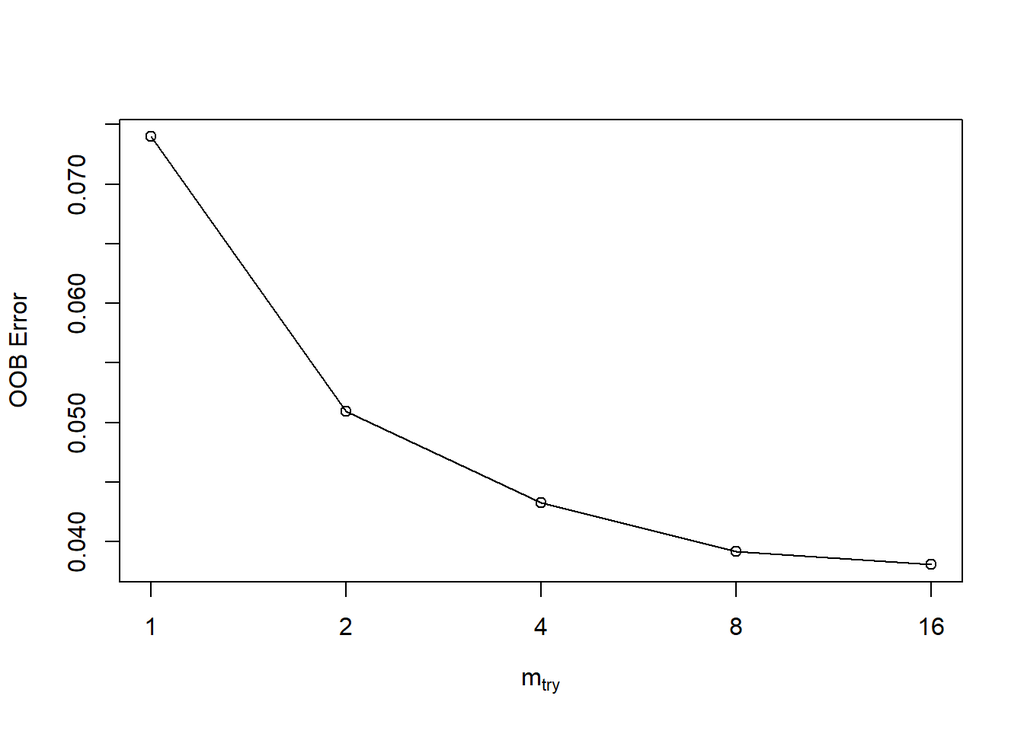

```
##        mtry   OOBError
## 1.OOB     1 0.07397888
## 2.OOB     2 0.05090799
## 4.OOB     4 0.04326998
## 8.OOB     8 0.03915535
## 16.OOB   16 0.03808145
```

The above result shows the OOB error rate under different mtry value. As the error difference between 8 and 16 are little, we’ll still choose 8 as the optimal mtry value eventually.

```r
set.seed(2)
survey1.ran.noise<-randomForest(satisfaction ~ ., data = survey1.tr.noise ,mtry = 8, importance=TRUE)
yhat.ran.noise <- predict(survey1.ran.noise, newdata = survey1.tst.noise)
```

By the importance figure, we can see that the noise factors doesn’t have significant influence on the whole model.

```r
acc_ran.noise<-mean(yhat.ran.noise == survey1.tst.noise$satisfaction)
acc_ran.noise
```

```
## [1] 0.9627878
```

```r
importance(survey1.ran.noise)
```

```
##                                             0           1 MeanDecreaseAccuracy
## Gender                              6.5691291  10.3769932            9.4250891
## Customer.Type                      55.0733952  98.9390514           87.0808786
## Age                                45.6160087  51.7431111           60.6406428
## Type.of.Travel                     60.6030275 155.0474037           99.6668990
## Class                              37.1968386  46.7265290           49.7895615
## Flight.Distance                    34.6359892  36.6176508           45.3339387
## Inflight.wifi.service             250.9645551  63.5913725          127.5307935
## Departure.Arrival.time.convenient  28.7216978  35.6119020           38.5136558
## Ease.of.Online.booking             31.7911386  29.6241768           37.9193856
## Gate.location                      37.2003282  31.5824069           33.3277140
## Food.and.drink                     17.4915131  29.9799827           29.3382836
## Online.boarding                    81.8742388  64.1674433           92.5835828
## Seat.comfort                       70.9936611  50.1005391           85.0372543
## Inflight.entertainment             41.8938612  42.6783987           53.1448391
## On.board.service                   55.8606042  32.4806787           56.4806965
## Leg.room.service                   44.5122121  34.6494638           46.9289924
## Baggage.handling                   76.4272489  45.7133140           88.5468785
## Checkin.service                    96.9839252  57.4765980          111.8588398
## Inflight.service                   75.2528890  30.4194139           77.7339505
## Cleanliness                        50.7705725  45.7067878           64.1689599
## Departure.Delay.in.Minutes         27.9745366  12.6906564           32.5552077
## Arrival.Delay.in.Minutes           31.8616605  29.7276196           42.4394814
## z1                                  0.9986220  -0.1190693            0.7196708
## z2                                 -0.2565730  -1.6140383           -1.1657599
## z3                                  1.5385566  -0.1903316            1.1322815
## z4                                 -0.6307365  -2.5419402           -1.9840977
##                                   MeanDecreaseGini
## Gender                                     73.0134
## Customer.Type                            1438.1856
## Age                                       889.4413
## Type.of.Travel                           3732.8854
## Class                                    4607.2043
## Flight.Distance                           868.7752
## Inflight.wifi.service                    6945.8875
## Departure.Arrival.time.convenient         702.3805
## Ease.of.Online.booking                   1037.3534
## Gate.location                             670.2908
## Food.and.drink                            325.4900
## Online.boarding                          8311.7100
## Seat.comfort                             1627.3251
## Inflight.entertainment                   2169.6046
## On.board.service                          881.9292
## Leg.room.service                         1186.8771
## Baggage.handling                          894.4506
## Checkin.service                           794.5175
## Inflight.service                          791.9143
## Cleanliness                               672.3105
## Departure.Delay.in.Minutes                261.8290
## Arrival.Delay.in.Minutes                  318.8202
## z1                                        460.5920
## z2                                        425.1631
## z3                                        296.6197
## z4                                        293.6107
```

Similarly, coefficients of noise factors for random forest model are significantly lower than most predictors in the original data set.

### Noise Factors Experiment

```r
data.frame(acc_lasso,acc_lasso.noise,acc_ran,acc_ran.noise)
```

```
##   acc_lasso acc_lasso.noise   acc_ran acc_ran.noise
## 1 0.8720498       0.8714224 0.9638979     0.9627878
```

The above dataframe compare the accuracy rates of models with noise factors and not with noise factors, we can note that adding few noise factors doesn’t seem to affect the final accuracy rate too much. Also, by the coefficient importance order, we can see that the noise factors don’t seem to have significant effect on the models, and we speculate the reason behind it may probably be the selection procedure by the two models.

### Conclusion: important aspects of the flight experience

To identify the important aspects of the flight experience related to customer satisfaction, let’s summarize the variable importance for the two models.

For the lasso regression model, “Customer.Type” and “Type.of.Travel” may be the factors that is worth evaluating if the company wants to improve the customer satisfaction. Since the two variables are mainly about the information of customers themselves; for this reason, the company could try to some provide customized services for different types of customers against their need.

As for random forest model, “Customer.Type” and “Type.of.Travel” also holds certain level of importance, and we additionally take “Online.boarding”, “Inflight.wifi.service”, “Checkin.service” such variables into consideration. That means customers really care about convenience of process related to check-in and boarding, and inflight wifi service is required for them to. In general, from the above descriptions, we can know that customers may pay attention the efficiency for the whole journey, and we can speculate that most of them are probably on business trip.

To conclude, customized services and improvement of convenience for the whole flight experience may be suggestions for achieving a higher customer satisfaction.